# Red Wine Quality

Maja Bedenikovic

2024-04-22

# 0. Intro

In the README file on Github, you can read intro information about the data set and variables in it. Here you will only find explanations of the code and the findings.

# 1. Verifying the type of data and null values

```r
str(data, na.rm=TRUE)
```

```
## 'data.frame':    1599 obs. of  12 variables:
##  $ fixed.acidity       : num  7.4 7.8 7.8 11.2 7.4 7.4 7.9 7.3 7.8 7.5 ...
##  $ volatile.acidity    : num  0.7 0.88 0.76 0.28 0.7 0.66 0.6 0.65 0.58 0.5 ...
##  $ citric.acid         : num  0 0 0.04 0.56 0 0 0.06 0 0.02 0.36 ...
##  $ residual.sugar      : num  1.9 2.6 2.3 1.9 1.9 1.8 1.6 1.2 2 6.1 ...
##  $ chlorides           : num  0.076 0.098 0.092 0.075 0.076 0.075 0.069 0.065 0.073 0.071 ...
##  $ free.sulfur.dioxide : num  11 25 15 17 11 13 15 15 9 17 ...
##  $ total.sulfur.dioxide: num  34 67 54 60 34 40 59 21 18 102 ...
##  $ density             : num  0.998 0.997 0.997 0.998 0.998 ...
##  $ pH                  : num  3.51 3.2 3.26 3.16 3.51 3.51 3.3 3.39 3.36 3.35 ...
##  $ sulphates           : num  0.56 0.68 0.65 0.58 0.56 0.56 0.46 0.47 0.57 0.8 ...
##  $ alcohol             : num  9.4 9.8 9.8 9.8 9.4 9.4 9.4 10 9.5 10.5 ...
##  $ quality             : int  5 5 5 6 5 5 5 7 7 5 ...
```

It shows us that all input variables are numerical (continuous), and quality is int (non-continuous) variable. In total we have 1.599 observations and 12 variables. Even with na.rm = TRUE, we have the same amount of observations.

# 2. About variables - summaries

```r
summary(data)
```

```
##  fixed.acidity   volatile.acidity  citric.acid    residual.sugar
##  Min.   : 4.60   Min.   :0.1200   Min.   :0.000   Min.   : 0.900
##  1st Qu.: 7.10   1st Qu.:0.3900   1st Qu.:0.090   1st Qu.: 1.900
##  Median : 7.90   Median :0.5200   Median :0.260   Median : 2.200
##  Mean   : 8.32   Mean   :0.5278   Mean   :0.271   Mean   : 2.539
##  3rd Qu.: 9.20   3rd Qu.:0.6400   3rd Qu.:0.420   3rd Qu.: 2.600
##  Max.   :15.90   Max.   :1.5800   Max.   :1.000   Max.   :15.500
##    chlorides       free.sulfur.dioxide total.sulfur.dioxide    density
##  Min.   :0.01200   Min.   : 1.00       Min.   :  6.00       Min.   :0.9901
##  1st Qu.:0.07000   1st Qu.: 7.00       1st Qu.: 22.00       1st Qu.:0.9956
##  Median :0.07900   Median :14.00       Median : 38.00       Median :0.9968
##  Mean   :0.08747   Mean   :15.87       Mean   : 46.47       Mean   :0.9967
##  3rd Qu.:0.09000   3rd Qu.:21.00       3rd Qu.: 62.00       3rd Qu.:0.9978
##  Max.   :0.61100   Max.   :72.00       Max.   :289.00       Max.   :1.0037
##        pH          sulphates         alcohol         quality
##  Min.   :2.740   Min.   :0.3300   Min.   : 8.40   Min.   :3.000
##  1st Qu.:3.210   1st Qu.:0.5500   1st Qu.: 9.50   1st Qu.:5.000
##  Median :3.310   Median :0.6200   Median :10.20   Median :6.000
##  Mean   :3.311   Mean   :0.6581   Mean   :10.42   Mean   :5.636
##  3rd Qu.:3.400   3rd Qu.:0.7300   3rd Qu.:11.10   3rd Qu.:6.000
##  Max.   :4.010   Max.   :2.0000   Max.   :14.90   Max.   :8.000
```

When it comes to skewness, we are always looking at mean and median value. If the mean is higher than median, then the distribution of the variable is skewed to the right (meaning that lower values are higher in number than higher values), and the other way around. In order to see what kind of distribution is it (we are always happy with a normal distribution, without extreme outliers), I’m using summaries to see the numerical part, and histogram and boxplot to see the graphic notations of the outliers and the shape of the distribution.

Let’s see on the graphs how these distributions really look like, and decide what we can do in case that it shows drastic outliers, and if the outliers are even a bad thing.

# Graphics of variables - identifying distributions and outliers

Below you can see the code and comments for the histograms of each variables. I’m using histograms first, to see the shape of the distributions, and possible outliers. Later on, I will give out the code for boxplots, for us to really see the dots which might represents possible outliers.

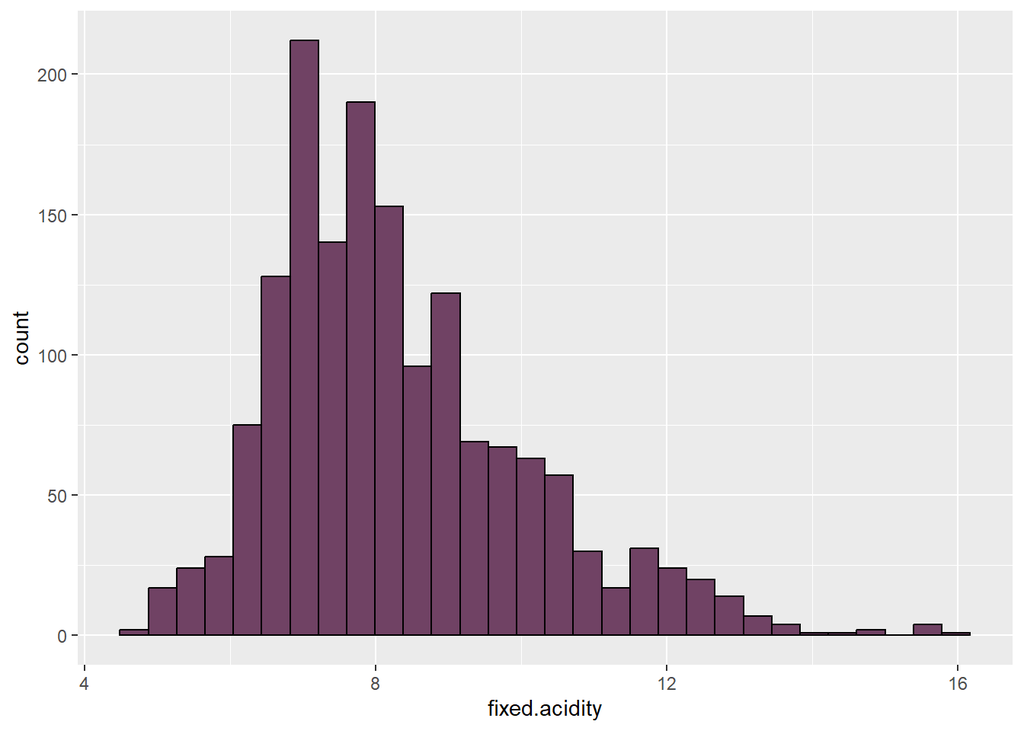

```r
ggplot(data,aes(x=fixed.acidity)) + geom_histogram(fill="#704264",colour="black") # has outliers on the high side
```

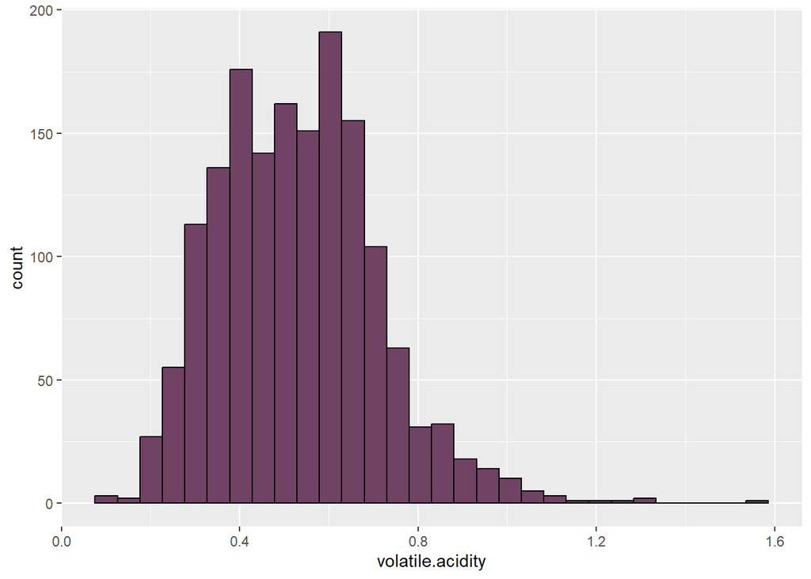

```r
ggplot(data,aes(x=volatile.acidity)) + geom_histogram(fill="#704264",colour="black") # has outliers on the high side
```

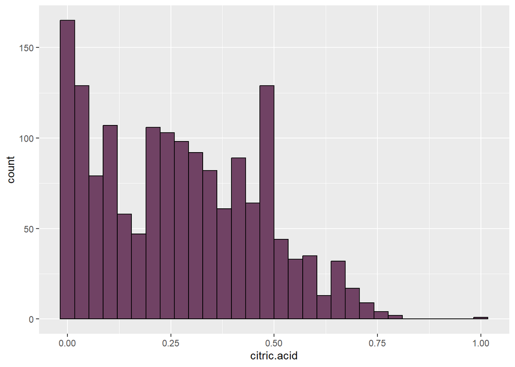

```r
ggplot(data,aes(x=citric.acid)) + geom_histogram(fill="#704264",colour="black") # has almost bimodal distribution, and outliers on the high side
```

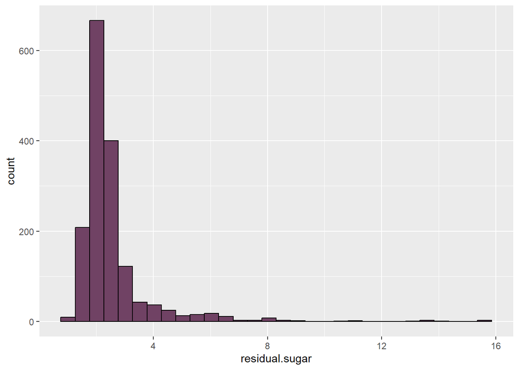

```r
ggplot(data,aes(x=residual.sugar)) + geom_histogram(fill="#704264",colour="black") # has outliers on the high side
```

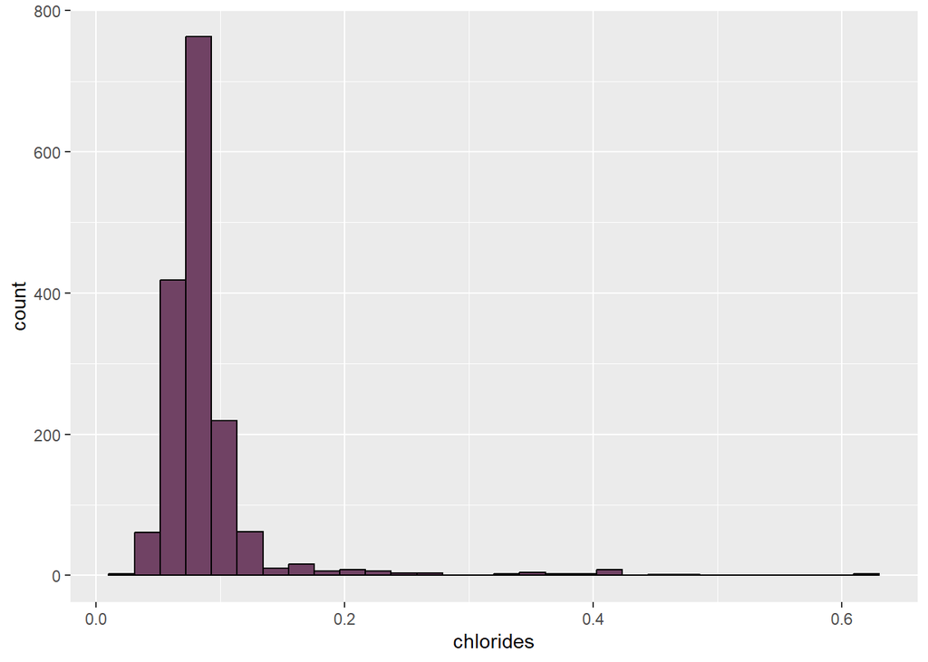

```r
ggplot(data,aes(x=chlorides)) + geom_histogram(fill="#704264",colour="black") # has outliers on the high side
```

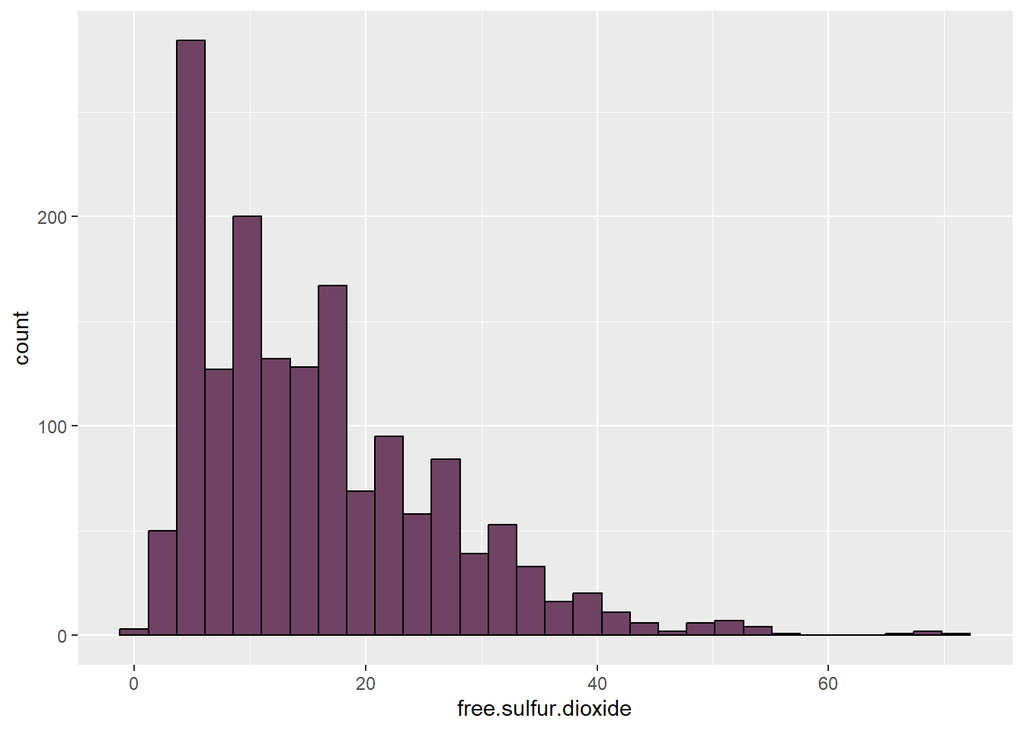

```r
ggplot(data,aes(x=free.sulfur.dioxide)) + geom_histogram(fill="#704264",colour="black") #h as outliers on the high side
```

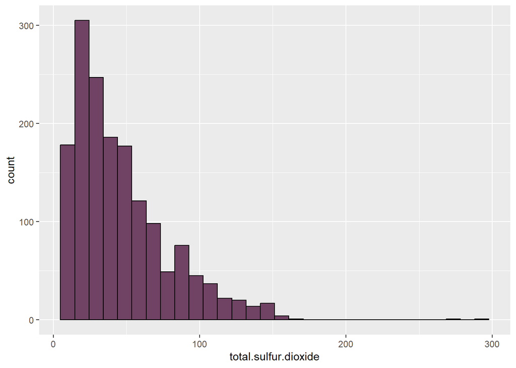

```r
ggplot(data,aes(x=total.sulfur.dioxide)) + geom_histogram(fill="#704264",colour="black") # has outliers on the high side
```

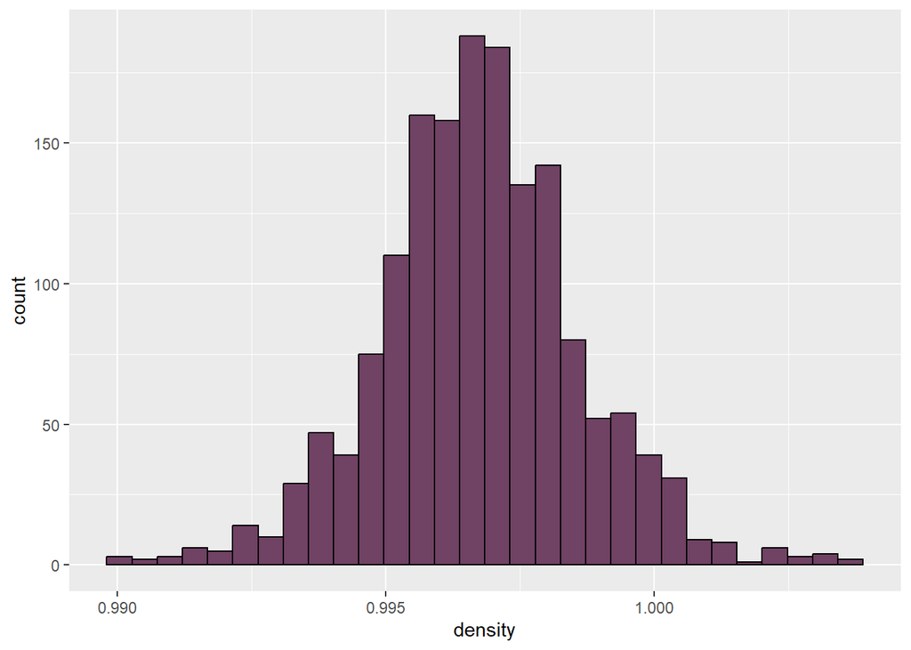

```r
ggplot(data,aes(x=density)) + geom_histogram(fill="#704264",colour="black") # has almost perfect distribution, nothing needs to be changed
```

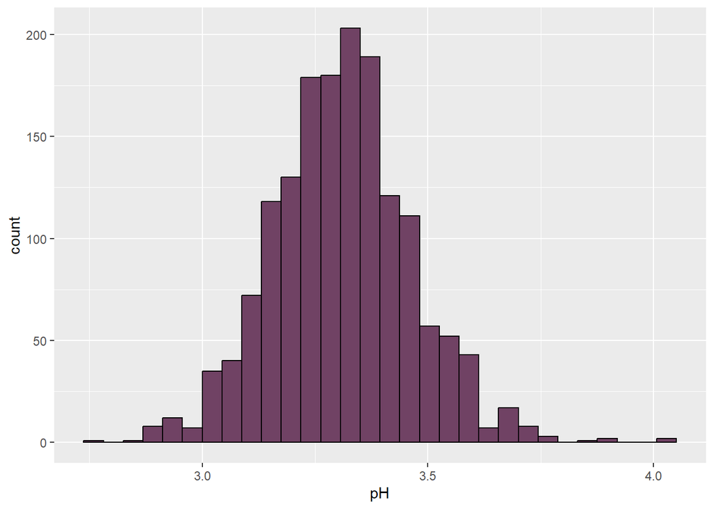

```r
ggplot(data,aes(x=pH)) + geom_histogram(fill="#704264",colour="black") # has almost perfect distribution, but still somewhat of visible outliers on high side
```

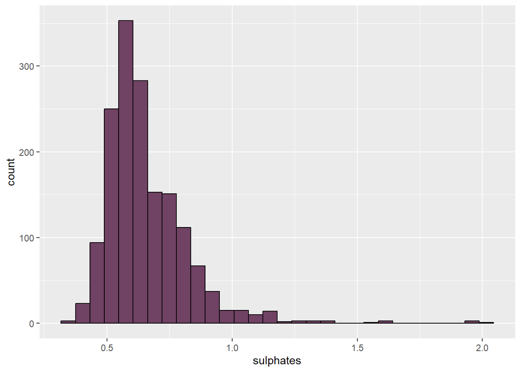

```r
ggplot(data,aes(x=sulphates)) + geom_histogram(fill="#704264",colour="black") # outliers on high side
```

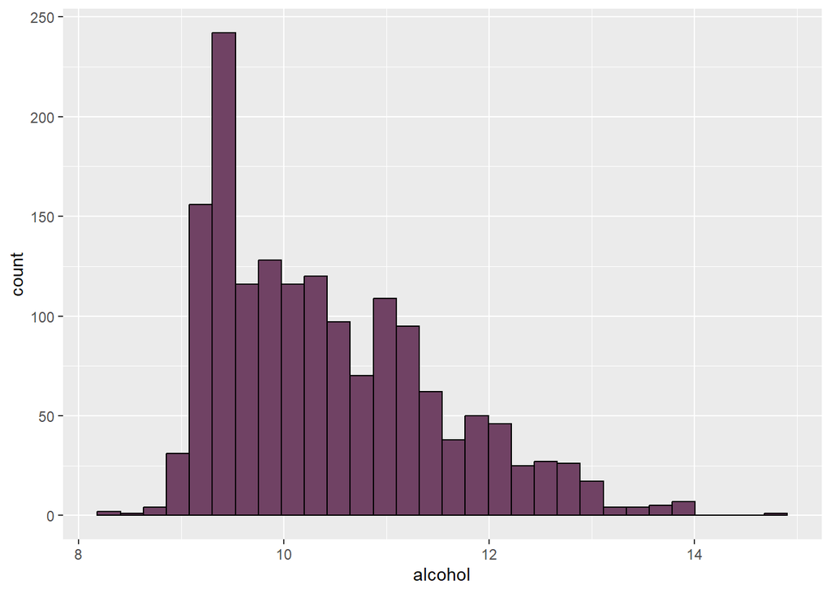

```r
ggplot(data,aes(x=alcohol)) + geom_histogram(fill="#704264",colour="black") # not definite distribution, with some outliers on the high side
```